# FigureYa130SVM_step12

小丫画图出品

2019-9-15

欢迎关注“小丫画图”公众号，同名知识星球等你加入

小丫微信: epigenomics E-mail: figureya@126.com

作者：罗丹de情人，齐德龙

小丫编辑校验

## 需求描述

筛选差异基因后，用cox regression、SVM-RFE和FW-SVM算法进一步筛选有预后意义的基因，组成基因甲基化位点或表达的signature。

[figure not shown]

出自https://onlinelibrary.wiley.com/doi/full/10.1111/jcmm.14231

主要分四步来实现，其中前两步在R里实现，后两步在python里实现，运行完本文档FigureYa130coxSVM_step12.Rmd之后，运行FigureYa130coxSVM_step34.ipynb：

- 第一步，正常人与癌症患者差异化比较
- 第二步，寻找相关矩阵，并生成下游数据
- 第三步，REF-SVM寻找合适的特征范围
- 第四步，FW-SVM进一步喜欢特征数目

## 环境设置

使用国内镜像安装包

```r
options("repos"= c(CRAN="https://mirrors.tuna.tsinghua.edu.cn/CRAN/"))
options(BioC_mirror="http://mirrors.ustc.edu.cn/bioc/")
#' @ChAMP所依赖的包巨多，请耐心等待安装
if (!requireNamespace("BiocManager", quietly = TRUE))
  install.packages("BiocManager")
BiocManager::install("ChAMP")
BiocManager::install(c("minfi","ChAMPdata","Illumina450ProbeVariants.db","sva",
                       "IlluminaHumanMethylation450kmanifest","limma","RPMM","DNAcopy",
                       "preprocessCore","impute","marray","wateRmelon","goseq","plyr","GenomicRanges",
                       "RefFreeEWAS","qvalue","isva","doParallel","bumphunter","quadprog",
                       "shiny","shinythemes","plotly","RColorBrewer","DMRcate","dendextend",
                       "IlluminaHumanMethylationEPICmanifest","FEM","matrixStats","missMethyl","combinat"))
```

加载包

```r
library(tidyverse)
library(ChAMP)
```

```
## locfit 1.5-9.1    2013-03-22
```

```
## Setting options('download.file.method.GEOquery'='auto')
```

```
## Setting options('GEOquery.inmemory.gpl'=FALSE)
```

[output not shown]

```r
library(minfi)
library(RColorBrewer)
library(survival)

Sys.setenv(LANGUAGE = "en") #显示英文报错信息
options(stringsAsFactors = FALSE) #禁止chr转成factor
```

## 输入文件下载

从XENAhttps://xenabrowser.net/datapages/下载两类数据，以GDC TCGA Liver Cancer (LIHC) (14 datasets)为例：

- 甲基化数据DNA methylation - Methylation450k，地址：https://xenabrowser.net/datapages/?dataset=TCGA-LIHC.methylation450.tsv&host=https%3A%2F%2Fgdc.xenahubs.net&removeHub=https%3A%2F%2Fxena.treehouse.gi.ucsc.edu%3A443，下载链接：https://gdc.xenahubs.net/download/TCGA-LIHC.methylation450.tsv.gz
- 生存数据phenotype, survival data (n=463) GDC Hub，https://xenabrowser.net/datapages/?dataset=TCGA-LIHC.survival.tsv&host=https%3A%2F%2Fgdc.xenahubs.net&removeHub=https%3A%2F%2Fxena.treehouse.gi.ucsc.edu%3A443，下载链接：https://gdc.xenahubs.net/download/TCGA-LIHC.survival.tsv.gz

```r
# 读入甲基化数据
nor_methy <- read_tsv("TCGA-LIHC.methylation450.tsv")
nor_methy <- column_to_rownames(nor_methy, var = "Composite Element REF")
nor_methy <- na.omit(nor_methy)

#########################
nor_methy[1:5,1:5]
```

```
##            TCGA-DD-A4NG-01A TCGA-G3-AAV4-01A TCGA-CC-A3M9-01A
## cg00000029        0.2942197       0.19336260        0.4246068
## cg00000165        0.1849303       0.06459059        0.1869270
## cg00000236        0.8772672       0.91009723        0.9222942
## cg00000289        0.7639439       0.81415849        0.8003798
## cg00000292        0.5351540       0.90197619        0.8857113
##            TCGA-G3-A5SI-01A TCGA-BC-A10W-01A
## cg00000029        0.4504546        0.1367256
## cg00000165        0.5231083        0.3106182
## cg00000236        0.9100894        0.9072093
## cg00000289        0.5340936        0.6881699
## cg00000292        0.7385950        0.6615239
```

```r
dim(nor_methy)
```

```
## [1] 369182    430
```

```r
##########################

# 读入生存数据
sur_data <- read.csv("TCGA-LIHC.survival.tsv",sep = "\t",header = T)
head(sur_data)
```

```
##             sample OS    X_PATIENT OS.time
## 1 TCGA-FV-A495-11A  0 TCGA-FV-A495       1
## 2 TCGA-FV-A495-01A  0 TCGA-FV-A495       1
## 3 TCGA-ED-A7PZ-01A  0 TCGA-ED-A7PZ       6
## 4 TCGA-ED-A97K-01A  0 TCGA-ED-A97K       6
## 5 TCGA-ED-A7PX-01A  0 TCGA-ED-A7PX       6
## 6 TCGA-BC-A3KF-01A  0 TCGA-BC-A3KF       8
```

```r
colnames(sur_data) <- c("sample", "OS_status", "ID", "OS_time")
sur_data <- sur_data[!is.na(sur_data$OS_time),]
sur_data <- sur_data[!is.na(sur_data$OS_status),]
sur_data <- sur_data[,c("ID","OS_time","OS_status")]
#去除急性进展患者对生存分析的影响
sur_data <- sur_data[sur_data$OS_time>30,]
dim(sur_data)
```

```
## [1] 435   3
```

```r
###################################
sur_data$OS_time <- sur_data$OS_time/30
head(sur_data)
```

```
##              ID  OS_time OS_status
## 29 TCGA-GJ-A6C0 1.033333         1
## 30 TCGA-GJ-A6C0 1.033333         1
## 31 TCGA-BC-A10Z 1.133333         1
## 32 TCGA-BC-A10Z 1.133333         1
## 33 TCGA-2Y-A9HA 1.200000         1
## 34 TCGA-DD-A73E 1.466667         0
```

```r
####################################
```

## 第一步，正常人与癌症患者差异化比较

```r
# 根据TCGA的barcode构建癌和癌旁的分类信号
sampleid <- colnames(nor_methy)
pdata <- data.frame(ID = sampleid,tissue_type = substring(sampleid,14,16))
head(pdata)
```

```
##                 ID tissue_type
## 1 TCGA-DD-A4NG-01A         01A
## 2 TCGA-G3-AAV4-01A         01A
## 3 TCGA-CC-A3M9-01A         01A
## 4 TCGA-G3-A5SI-01A         01A
## 5 TCGA-BC-A10W-01A         01A
## 6 TCGA-DD-AACV-01A         01A
```

```r
summary(as.factor(pdata$tissue_type))
```

```
## 01A 01B 02A 02B 11A
## 375   2   2   1  50
```

```r
pdata <- pdata[!pdata$tissue_type=="01B",]
pdata <- pdata[!pdata$tissue_type=="02B",]
pdata$group <- ifelse(pdata$tissue_type=="11A","normal","tumor")
summary(as.factor(pdata$group))
```

```
## normal  tumor
##     50    377
```

```r
##########################
nor_methy <- nor_methy[,colnames(nor_methy)%in%pdata$ID]
dim(nor_methy)
```

```
## [1] 369182    427
```

```r
pdata <- pdata[match(colnames(nor_methy),pdata$ID),]
data.frame(pdata$ID,colnames(nor_methy))
```

[output not shown]

[output cut: 413 more lines]

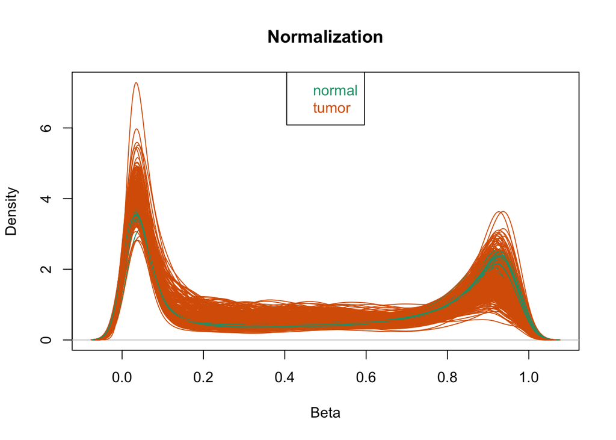

```r
##########################
save(nor_methy,pdata,file = "input.RData")

#查看数据标准化的结果
##########################
# visualise what the data looks like before and after normalisation
densityPlot(as.matrix(nor_methy), sampGroups=pdata$group,main="Normalization", legend=FALSE)
legend("top", legend = levels(factor(pdata$group)),
       text.col=brewer.pal(8,"Dark2"))
```

```r
#从结果来看UCSC这个标准化做的并不好
#########################

# 正常人与癌症患者差异化比较
#' @find-Differential-Methylation-Probes
myDMP <- champ.DMP(beta = nor_methy,pheno=pdata$group)
```

```
## [===========================]
```

```
## [<<<<< ChAMP.DMP START >>>>>]
```

```
## !!! Important !!! New Modification has been made on champ.DMP():
```

```
##     (1): In this version champ.DMP() if your pheno parameter contains more than two groups of phenotypes, champ.DMP() would do pairewise differential methylated analysis between each pair of them. But you can also specify compare.group to only do comparasion between any two of them.
```

```
##     (2): champ.DMP() now support numeric as pheno, and will do linear regression on them. So covariates like age could be inputted in this function. You need to make sure your inputted "pheno" parameter is "numeric" type.
```

```
##
## [ Section 1:  Check Input Pheno Start ]
```

```
##   You pheno is character type.
```

```
##     Your pheno information contains following groups. >>
```

```
##     <tumor>:377 samples.
```

```
##     <normal>:50 samples.
```

```
##     [The power of statistics analysis on groups contain very few samples may not strong.]
```

```
##     pheno contains only 2 phenotypes
```

```
##     compare.group parameter is NULL, two pheno types will be added into Compare List.
```

```
##     tumor_to_normal compare group : tumor, normal
```

```
##
## [ Section 1:  Check Input Pheno Done ]
```

```
##
## [ Section 2:  Find Differential Methylated CpGs Start ]
```

```
##   Start to Compare : tumor, normal
```

```
##   Contrast Matrix
```

```
##          Contrasts
## Levels    ptumor-pnormal
##   pnormal             -1
##   ptumor               1
```

```
##   You have found 234047 significant MVPs with a BH adjusted P-value below 0.05.
```

```
##   Calculate DMP for tumor and normal done.
```

```
##
## [ Section 2:  Find Numeric Vector Related CpGs Done ]
```

```
##
## [ Section 3:  Match Annotation Start ]
```

```
##
## [ Section 3:  Match Annotation Done ]
```

```
## [<<<<<< ChAMP.DMP END >>>>>>]
```

```
## [===========================]
```

```
## [You may want to process DMP.GUI() or champ.GSEA() next.]
```

```r
head(myDMP[[1]])
```

```
##                      logFC    AveExpr         t       P.Value
## cg13814654      0.32176508 0.87949581  32.45779 3.137983e-117
## cg13053914      0.19091944 0.93662549  31.24544 2.886556e-112
## cg26915558      0.35813661 0.85851615  29.10098 2.667584e-103
## cg13894813      0.32497158 0.85527760  28.28911 7.579257e-100
## ch.10.2610459F -0.08029293 0.04256889 -27.02505  2.074986e-94
## ch.7.135065R   -0.25331646 0.10424283 -26.65665  8.218623e-93
##                    adj.P.Val        B  tumor_AVG normal_AVG   deltaBeta
## cg13814654     1.158487e-111 256.7105 0.91717322  0.5954081 -0.32176508
## cg13053914     5.328323e-107 245.3816 0.95898140  0.7680620 -0.19091944
## cg26915558      3.282747e-98 224.9062 0.90045252  0.5423159 -0.35813661
## cg13894813      6.995313e-95 217.0153 0.89333048  0.5683589 -0.32497158
## ch.10.2610459F  1.532095e-89 204.5876 0.03316691  0.1134598  0.08029293
## ch.7.135065R    5.056946e-88 200.9348 0.07458048  0.3278969  0.25331646
##                CHR   MAPINFO Strand Type   gene feature     cgi
## cg13814654       2 101666894      R   II TBC1D8    Body opensea
## cg13053914       7  75511260      R    I RHBDD2    Body   shelf
## cg26915558      11  68181218      F   II   LRP5    Body  island
## cg13894813      11  68181087      R   II   LRP5    Body  island
## ch.10.2610459F  10 123286731      F   II  FGFR2    Body opensea
## ch.7.135065R     7   2696746      F   II  TTYH3    Body   shore
##                    feat.cgi   UCSC_CpG_Islands_Name  DHS Enhancer Phantom
## cg13814654     Body-opensea                           NA       NA
## cg13053914       Body-shelf  chr7:75508166-75508759   NA       NA
## cg26915558      Body-island chr11:68181086-68181289   NA       NA
## cg13894813      Body-island chr11:68181086-68181289 TRUE       NA
## ch.10.2610459F Body-opensea                           NA     TRUE
## ch.7.135065R     Body-shore    chr7:2697934-2698204   NA       NA
##                Probe_SNPs Probe_SNPs_10
## cg13814654
## cg13053914
## cg26915558
## cg13894813
## ch.10.2610459F rs41295525
## ch.7.135065R
```

```r
dmp <- myDMP[[1]]
dmp <- dmp[dmp$adj.P.Val<0.05 & abs(dmp$deltaBeta)>0.2,]
dim(dmp)
```

```
## [1] 47566    23
```

```r
###########################
dmp <- unique(rownames(dmp))
length(dmp)
```

```
## [1] 47566
```

```r
############################

#提取肿瘤的差异化甲基化位点矩阵
tumor_id <- as.character(pdata[pdata$group=="tumor","ID"]);tumor_id
```

```
##   [1] "TCGA-DD-A4NG-01A" "TCGA-G3-AAV4-01A" "TCGA-CC-A3M9-01A"
##   [4] "TCGA-G3-A5SI-01A" "TCGA-BC-A10W-01A" "TCGA-DD-AACV-01A"
##   [7] "TCGA-DD-AAD3-01A" "TCGA-DD-A1EI-01A" "TCGA-G3-AAV2-01A"
##  [10] "TCGA-DD-AAE8-01A" "TCGA-DD-AACT-01A" "TCGA-GJ-A6C0-01A"
##  [13] "TCGA-CC-5258-01A" "TCGA-RC-A6M5-01A" "TCGA-DD-AADP-01A"
##  [16] "TCGA-DD-AACW-01A" "TCGA-ZS-A9CD-01A" "TCGA-UB-A7MF-01A"
##  [19] "TCGA-WX-AA46-01A" "TCGA-CC-A8HV-01A" "TCGA-DD-AADQ-01A"
##  [22] "TCGA-2Y-A9H6-01A" "TCGA-DD-A1EA-01A" "TCGA-5R-AA1C-01A"
##  [25] "TCGA-DD-A113-01A" "TCGA-2Y-A9H9-01A" "TCGA-CC-A7IE-01A"
##  [28] "TCGA-XR-A8TD-01A" "TCGA-DD-AACY-01A" "TCGA-CC-A9FV-01A"
##  [31] "TCGA-ED-A4XI-01A" "TCGA-CC-A9FW-01A" "TCGA-DD-A4NP-01A"
##  [34] "TCGA-G3-A5SJ-01A" "TCGA-CC-A1HT-01A" "TCGA-CC-A8HS-01A"
##  [37] "TCGA-DD-AADV-01A" "TCGA-2Y-A9GS-01A" "TCGA-DD-A4NE-01A"
##  [40] "TCGA-DD-AADC-01A" "TCGA-DD-AAVZ-01A" "TCGA-DD-AAVV-01A"
##  [43] "TCGA-2Y-A9GY-01A" "TCGA-ZS-A9CF-01A" "TCGA-ED-A627-01A"
```

[output cut: 111 more lines]

```r
tumor_methy <- nor_methy[dmp,colnames(nor_methy)%in%tumor_id]
dim(tumor_methy)
```

```
## [1] 47566   377
```

```r
#把前面的运行结果保存一下
save(tumor_methy,file = "TCGA-LIHC-Tumor-dmp-matrix.RData")
```

## 第二步，寻找相关矩阵，并生成下游数据

```r
#读入第一步的运行结果
(load("TCGA-LIHC-Tumor-dmp-matrix.RData"))
```

```
## [1] "tumor_methy"
```

```r
colnames(tumor_methy) <- substring(colnames(tumor_methy),1,12)
tumor_methy <- as.data.frame(t(tumor_methy))
tumor_methy[1:5,1:6]
```

```
##              cg13814654 cg26915558 cg13894813 ch.7.135065R cg24985525
## TCGA.DD.A4NG  0.9516489  0.9397856  0.9355568   0.08872650  0.9386242
## TCGA.G3.AAV4  0.9210649  0.9350214  0.9472769   0.19701485  0.9388979
## TCGA.CC.A3M9  0.9251027  0.9214369  0.9085828   0.02121358  0.9342625
## TCGA.G3.A5SI  0.9540869  0.9549477  0.9444060   0.03663726  0.9568113
## TCGA.BC.A10W  0.9216781  0.9176186  0.8589716   0.04769915  0.9538389
##              cg19786751
## TCGA.DD.A4NG  0.9169950
## TCGA.G3.AAV4  0.9134047
## TCGA.CC.A3M9  0.9273913
## TCGA.G3.A5SI  0.9444138
## TCGA.BC.A10W  0.9267142
```

```r
tumor_methy <- rownames_to_column(tumor_methy,var = "ID")
tumor_methy$ID <- gsub(tumor_methy$ID,pattern = "\\.",replacement = "-")
tumor_methy <- tumor_methy[!duplicated(tumor_methy$ID),]

summary(tumor_methy$ID%in%sur_data$ID)
```

```
##    Mode   FALSE    TRUE
## logical      31     346
```

```r
################################
sur_meth <- merge(sur_data,tumor_methy,by.x="ID",by.y="ID",all.x=F,all.y=F)
```

如果想要获得HR和可信区间，使用批量生存分析，运行时间较长-patience

```r
Coxoutput=data.frame()
for(i in colnames(sur_meth[,4:ncol(sur_meth)])){
  cox <- coxph(Surv(OS_time,OS_status) ~ sur_meth[,i], data = sur_meth)
  coxSummary = summary(cox)
  Coxoutput=rbind(Coxoutput,cbind(gene=i,HR=coxSummary$coefficients[,"exp(coef)"],
                                  z=coxSummary$coefficients[,"z"],
                                  pvalue=coxSummary$coefficients[,"Pr(>|z|)"],
                                  lower=coxSummary$conf.int[,3],
                                  upper=coxSummary$conf.int[,4]))
}
for(i in c(2:6)){
  Coxoutput[,i] <- as.numeric(as.vector(Coxoutput[,i]))
}
Coxoutput <- arrange(Coxoutput,pvalue)  %>% #用pvalue筛选
  filter(pvalue < 0.05)
dim(Coxoutput)
```

```
## [1] 5696    6
```

```r
head(Coxoutput)
```

```
##         gene          HR         z       pvalue      lower      upper
## 1 cg24282479  0.09041342 -6.337886 2.329384e-10 0.04299841  0.1901137
## 2 cg01634213  0.12615653 -5.749676 8.941487e-09 0.06229104  0.2555018
## 3 cg06968788  0.12530781 -5.679994 1.346998e-08 0.06119592  0.2565865
## 4 cg04118741  0.19211450 -5.504233 3.707791e-08 0.10676971  0.3456784
## 5 cg14575983 16.82337919  5.501289 3.770255e-08 6.15393200 45.9910977
## 6 cg19811994  0.13213556 -5.442023 5.267882e-08 0.06374584  0.2738972
```

```r
################################

sig_dmp <- as.character(Coxoutput$gene);sig_dmp[1:100]
```

```
##   [1] "cg24282479" "cg01634213" "cg06968788" "cg04118741" "cg14575983"
##   [6] "cg19811994" "cg16603012" "cg05557266" "cg17182270" "cg25765315"
##  [11] "cg00546307" "cg03056854" "cg00980904" "cg02710090" "cg14266287"
##  [16] "cg13313836" "cg14420613" "cg27505349" "cg02910574" "cg10346364"
##  [21] "cg08912860" "cg24652919" "cg06613738" "cg13489987" "cg04465154"
##  [26] "cg25497530" "cg22971920" "cg09134497" "cg04403423" "cg25367206"
##  [31] "cg02311374" "cg07703079" "cg17890940" "cg01221209" "cg19985421"
##  [36] "cg08419450" "cg26357403" "cg22353097" "cg11188031" "cg06158650"
##  [41] "cg07584765" "cg24156261" "cg21460081" "cg13414270" "cg21139496"
##  [46] "cg20253105" "cg11062848" "cg01927000" "cg13919908" "cg11418477"
##  [51] "cg24040043" "cg20716202" "cg22274117" "cg09021225" "cg26651775"
##  [56] "cg10995381" "cg26579550" "cg16603578" "cg22131172" "cg07896068"
##  [61] "cg21196487" "cg09928027" "cg22626683" "cg00242031" "cg13585675"
##  [66] "cg23920016" "cg05304531" "cg24056751" "cg24631526" "cg23565821"
##  [71] "cg02466113" "cg08373769" "cg22786667" "cg01426968" "cg21827674"
##  [76] "cg00608661" "cg25985683" "cg06030535" "cg27185510" "cg25742037"
##  [81] "cg23338773" "cg10492657" "cg00093688" "cg06082598" "cg20873416"
##  [86] "cg01406381" "cg19547192" "cg03089870" "cg20155875" "cg02461502"
##  [91] "cg06570967" "cg09298313" "cg08043565" "cg05671644" "cg09218076"
##  [96] "cg19290938" "cg06617217" "cg11173246" "cg09341491" "cg22637867"
```

进一步筛选tumor_methy-矩阵文件-用于向量机的进一步筛选

```r
rownames(tumor_methy) <- NULL
tumor_methy <- column_to_rownames(tumor_methy,var = "ID")
tumor_methy <- tumor_methy[rownames(tumor_methy)%in%sur_meth$ID,colnames(tumor_methy)%in%sig_dmp]
tumor_methy <- rownames_to_column(tumor_methy,var = "ID")
dim(tumor_methy)
```

```
## [1]  346 5697
```

```r
tumor_methy[1:5,1:5]
```

```
##             ID ch.7.135065R cg21072795 ch.7.2184863F cg27120934
## 1 TCGA-DD-A4NG   0.08872650 0.17278296    0.06152867 0.02707180
## 2 TCGA-CC-A3M9   0.02121358 0.37392894    0.06180780 0.12078751
## 3 TCGA-G3-A5SI   0.03663726 0.16209972    0.05235341 0.04718153
## 4 TCGA-BC-A10W   0.04769915 0.08224918    0.04725225 0.27235586
## 5 TCGA-DD-AACV   0.02399076 0.03301908    0.04911178 0.04678203
```

患者风险分析

```r
sur_data <- sur_data[sur_data$ID%in%sur_meth$ID,]
sur_data <- within(sur_data, {
  subtype <- NA
  subtype[(OS_time <= 12) & (OS_status == 1)] <- "High_risk"
  subtype[(OS_time >= 60) ] <- "Low_risk"
})

sur_data$subtype[is.na(sur_data$subtype)] <- "Inter_risk"
summary(as.factor(sur_data$subtype))
```

```
##  High_risk Inter_risk   Low_risk
##         63        307         63
```

```r
tumor_subtype_methy <- merge(sur_data[,c("ID","subtype")],tumor_methy,by.x="ID",by.y="ID",all.x=F,all.y=F)
tumor_subtype_methy[1:5,1:10]
```

```
##             ID    subtype ch.7.135065R cg21072795 ch.7.2184863F cg27120934
## 1 TCGA-2Y-A9GS Inter_risk   0.03326956  0.1201778    0.04465894 0.03700273
## 2 TCGA-2Y-A9GT Inter_risk   0.03418858  0.2538940    0.05229601 0.08390235
## 3 TCGA-2Y-A9GU   Low_risk   0.08902994  0.2335061    0.16958221 0.06066605
## 4 TCGA-2Y-A9GV   Low_risk   0.09814426  0.2549827    0.14381460 0.06293260
## 5 TCGA-2Y-A9GW Inter_risk   0.04223428  0.1666599    0.07057743 0.06679864
##   ch.1.64660926R cg25792518 cg15364131 ch.16.82520294R
## 1     0.05448898  0.8200375 0.03987176      0.06676943
## 2     0.04036911  0.8688741 0.11417553      0.09893396
## 3     0.23610088  0.7788349 0.03758744      0.17115091
## 4     0.06596693  0.2496782 0.03914273      0.12280947
## 5     0.05022552  0.5392192 0.02759508      0.04809626
```

```r
save(tumor_subtype_methy,file = "TCGA-LIHC-survival-relevant-DMP-matrix.RData")
write.csv(tumor_subtype_methy,"TCGA-LIHC-survival-relevant-DMP-matrix.csv")
```

接下来将进入第三和第四步，请打开FigureYa130coxSVM_step34.ipynb文件，以第二步生成的TCGA-LIHC-survival-relevant-DMP-matrix.csv文件作为输入。